# Deep-sea like OM: Data & Multi-area Projections (Lophius, WKLIFE)

Ernesto Jardim

2026-09-09

# 1 Introduction

This report builds a deep-sea-like operating model (OM) based on the life-history parameters of *Lophius* (monkfish), as used in WKLIFE. It combines two stages that previously lived in separate scripts, run here in a single knit:

1. **Data build**: derive growth, weight, natural mortality, maturity, selectivity, and a stock-recruitment relationship from life-history parameters, then build an `FLBRP`/`FLStock` (`stk0`) and apply a historical fishing trajectory at Fmsy.
2. **Operating model**: split `stk0` into three areas — two submarine mounts subject to fishing (`a` and `b`) and one refuge area not subject to fishing (`c`) — sharing a common stock-recruitment relationship, and project forward under three movement scenarios.

Because everything runs in one document, the objects produced in Part 1 (`stk0`, `sr`, `a50`, …) are simply reused in Part 2 — no intermediate `.RData` file is written or loaded.

```r
install.packages(c("tidyr", "dplyr", "ggplot2"))
install.packages(pkgs = c("FLCore", "FLasher", "FLife"),
  repos = c(FLR = "https://flr.r-universe.dev",
            CRAN = "https://cloud.r-project.org"))
```

```r
library(FLife)
library(FLasher)
library(ggplot2)
library(tidyr)
library(dplyr)
```

# 2 Part 1: Generate a stock from life-history parameters (FLife)

## 2.1 Life-history parameters

```r
# stocks and life-history parameters
stocks_lh <- read.csv("stocks.csv")

# select lophius
lh <- stocks_lh[1, ]
agevec <- seq(0, 90, 2)
```

## 2.2 Growth

```r
# von Bertalanffy parameters
lh[c("linf", "k", "t0")]
```

```
##    linf    k   t0
## 1 110.1 0.08 0.39
```

```r
tmax <- lh$t0 - log(0.05) / lh$k
```

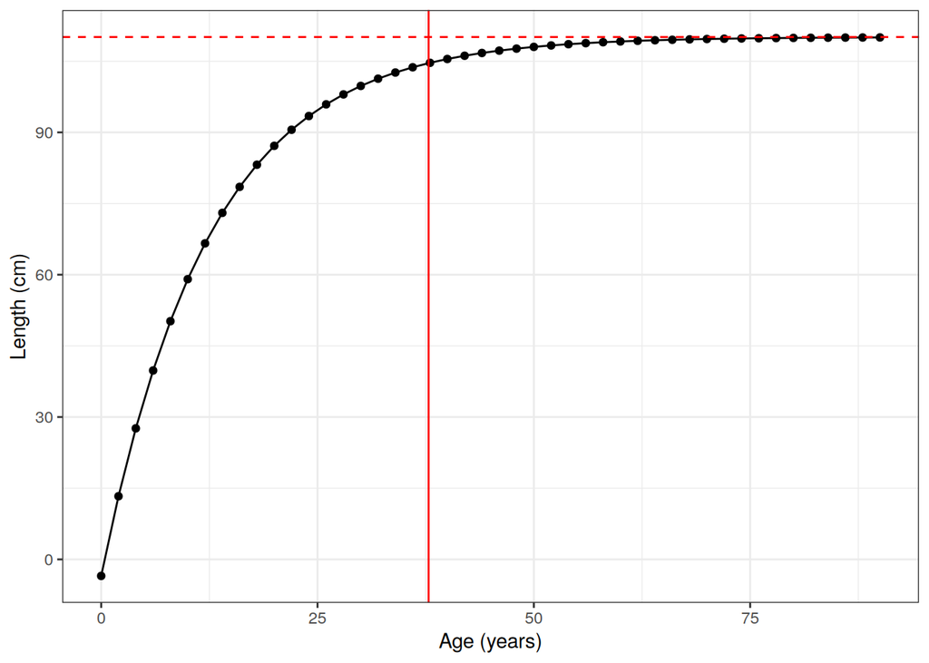

```r
df_length <- data.frame(age = agevec)
df_length$length <- vonB(df_length$age, params = FLPar(lh))

df_length %>%
  ggplot(aes(x = age, y = length)) +
  geom_line() +
  geom_point(data = . %>% filter(age %in% agevec)) +
  geom_hline(yintercept = lh$linf, colour = "red", linetype = "dashed") +
  geom_vline(xintercept = tmax, colour = "red") +
  labs(x = "Age (years)", y = "Length (cm)") +
  theme_bw()
```

## 2.3 Length-weight relationship

```r
lh[c("a", "b")]
```

```
##        a     b
## 1 0.0259 2.858
```

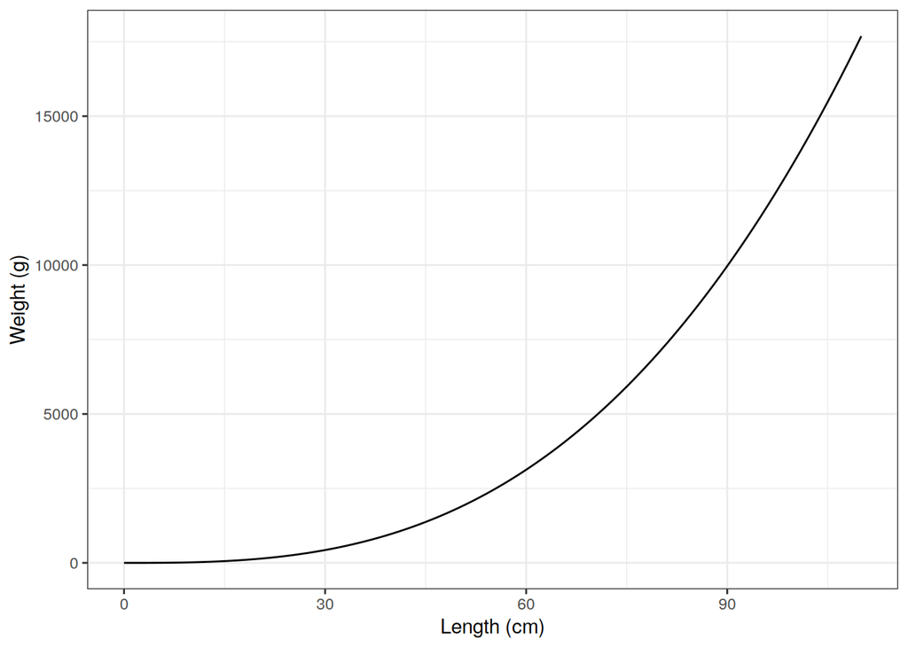

```r
data.frame(length = seq(0, lh$linf),
           weight = c(lh$a * seq(0, lh$linf)^lh$b)) %>%
  ggplot(aes(x = length, y = weight)) +
  geom_line() +
  labs(x = "Length (cm)", y = "Weight (g)") +
  theme_bw()
```

## 2.4 Weight at age

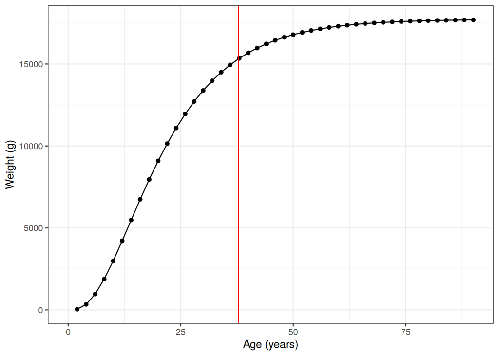

```r
df_length$weight <- lh$a * df_length$length^lh$b

df_length %>%
  ggplot(aes(x = age, y = weight)) +
  geom_line() +
  geom_point(data = . %>% filter(age %in% agevec)) +
  geom_vline(xintercept = tmax, colour = "red") +
  labs(x = "Age (years)", y = "Weight (g)") +
  theme_bw()
```

## 2.5 Natural mortality

```r
df_length$M <- rep(1.5 * lh["k"], nrow(df_length))

#df_length %>%
#  ggplot(aes(x = age, y = M)) +
#  geom_line() +
#  geom_point(data = . %>% filter(age %in% agevec)) +
#  geom_vline(xintercept = tmax, colour = "red") +
#  labs(x = "Age (years)", y = "Natural mortality") +
#  theme_bw() +
#  coord_cartesian(ylim = c(0, 3))
```

## 2.6 Maturity

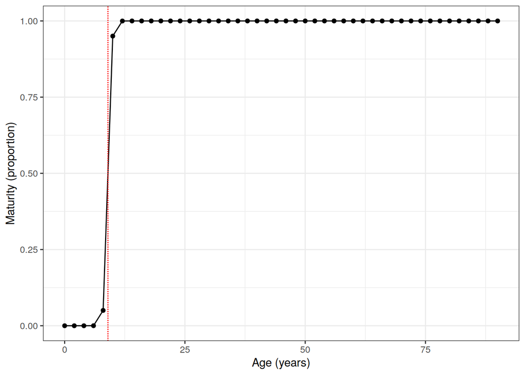

```r
# calculate a50
a50 <- vonB(len = FLQuant(lh$l50), params = FLPar(lh))

# create template for ages
ages_tmp <- FLQuant(agevec, dimnames = list(age = agevec))
mat_tmp <- FLife:::logisticFn(age = ages_tmp,
                               params = FLPar(a50 = a50, asym = 1, ato95 = 1))

as.data.frame(mat_tmp) %>%
  ggplot(aes(x = age, y = data)) +
  geom_line() +
  geom_point(data = . %>% filter(age %in% 0:90)) +
  geom_vline(xintercept = a50, colour = "red", linetype = "1111") +
  labs(x = "Age (years)", y = "Maturity (proportion)") +
  theme_bw()
```

## 2.7 Selectivity

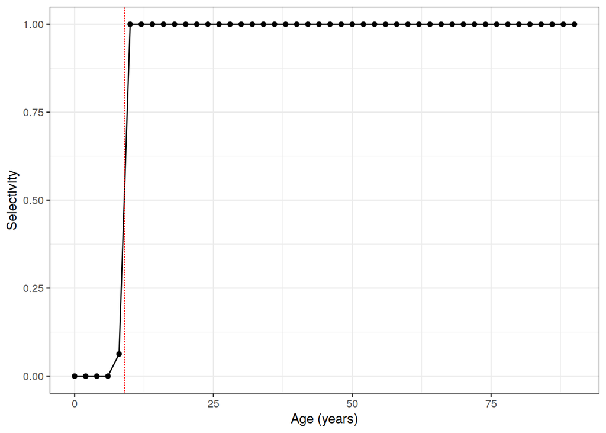

```r
# create template for ages
ages_tmp <- FLQuant(agevec, dimnames = list(age = agevec))
sel_tmp <- FLife:::dnormalFn(age = ages_tmp,
                              params = FLPar(sel1 = a50 + 1, sel2 = 1, sel3 = 5000))

as.data.frame(sel_tmp) %>%
  ggplot(aes(x = age, y = data)) +
  geom_line() +
  geom_point(data = . %>% filter(age %in% agevec)) +
  geom_vline(xintercept = a50, colour = "red", linetype = "1111") +
  labs(x = "Age (years)", y = "Selectivity") +
  theme_bw()
```

## 2.8 Stock-recruitment relationship

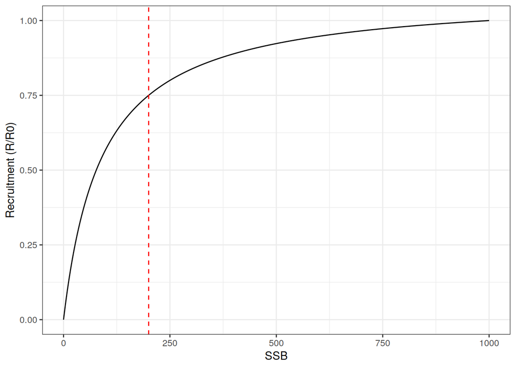

```r
# define unfished biomass and recruitment steepness
lh$v <- 1000 ### unfished SSB (arbitrary)
lh$s <- 0.75 ### recruitment steepness (arbitrary)

# plot stock-recruitment relationship
# (relative to unfished recruitment, R0)
R0 <- 1 ### for plotting only
df_r <- data.frame(SSB = 0:1000)
df_r$R <- (0.8 * R0 * lh$s * df_r$SSB) /
  (0.2 * lh$v * (1 - lh$s) + (lh$s - 0.2) * df_r$SSB)

df_r %>%
  ggplot(aes(x = SSB, y = R)) +
  geom_line() +
  geom_vline(xintercept = 0.2 * lh$v, colour = "red", linetype = "dashed") +
  labs(x = "SSB", y = "Recruitment (R/R0)") +
  theme_bw()
```

## 2.9 Building the FLBRP and FLStock objects

```r
# generate FLPar object with life-history parameters
lh_pars <- lhPar(lh[c("linf", "k", "t0", "a", "b", "l50", "s", "v")])

# create FLBRP with reference points
brp <- lhEql(lh_pars, range = c(min = 1, max = ceiling(tmax),
                                 minfbar = 1, maxfbar = ceiling(tmax),
                                 plusgroup = floor(tmax)))

# show reference points
refpts(brp)
```

```
## An object of class "FLPar"
##         quant
## refpt    harvest   yield     rec       ssb       biomass   revenue   cost
##   virgin  0.00e+00  0.00e+00  5.22e+03  1.00e+03  1.66e+04        NA        NA
##   msy     6.18e-02  2.02e+01  4.20e+03  2.56e+02  1.28e+04        NA        NA
##   crash   2.80e-01  1.72e-06  2.97e-04  4.74e-06  8.94e-04        NA        NA
##   f0.1    5.59e-02  2.01e+01  4.31e+03  2.83e+02  1.32e+04        NA        NA
##   fmax    5.00e-01 -2.63e+01 -4.52e+03 -4.03e+01 -1.36e+04        NA        NA
##         quant
## refpt    profit
##   virgin        NA
##   msy           NA
##   crash         NA
##   f0.1          NA
##   fmax          NA
## units:  NA
```

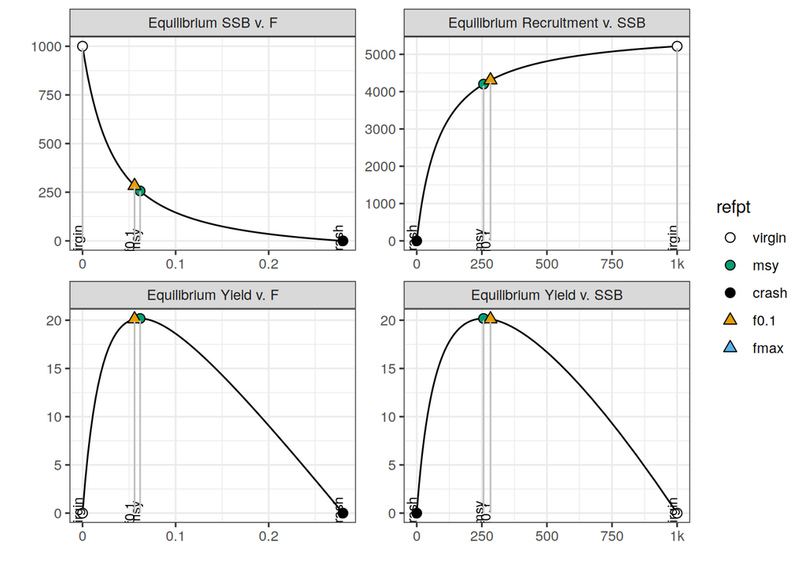

```r
# for plotting, remove Fmax
refpts(brp)["fmax", ] <- NA
plot(brp) + theme_bw()
```

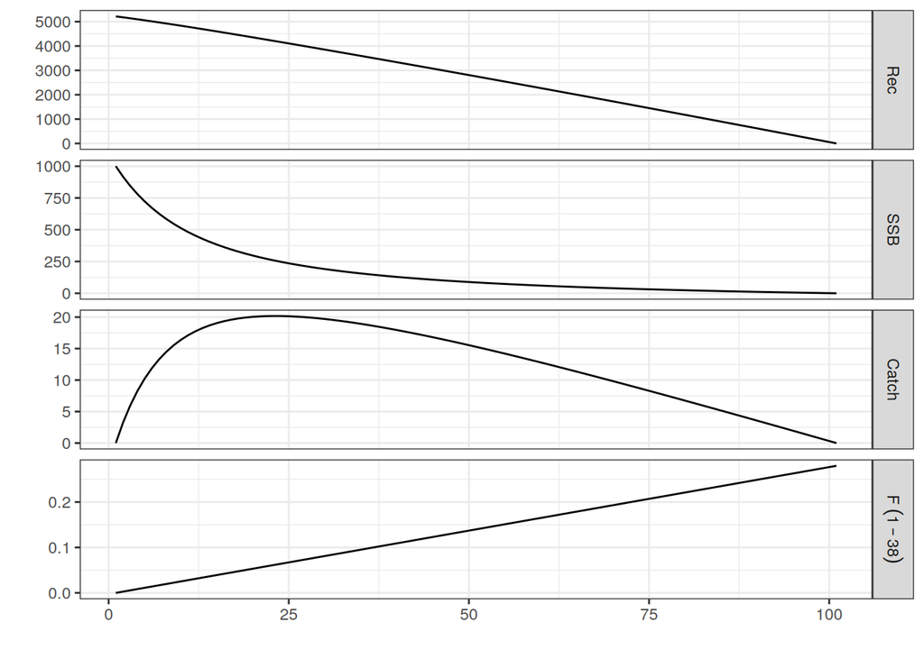

```r
# get stock
stk0 <- as(brp, "FLStock")
plot(stk0) + theme_bw()
```

```r
# get stock-recruitment model object
sr <- FLSR(params = params(brp), model = model(brp))
model(sr)
```

```
## rec ~ a * ssb/(b + ssb)
## <environment: 0x177e6468>
```

```r
params(sr)
```

```
## An object of class "FLPar"
## params
##      a      b
## 5690.7   90.9
## units:  NA
```

## 2.10 Fishing history at Fmsy

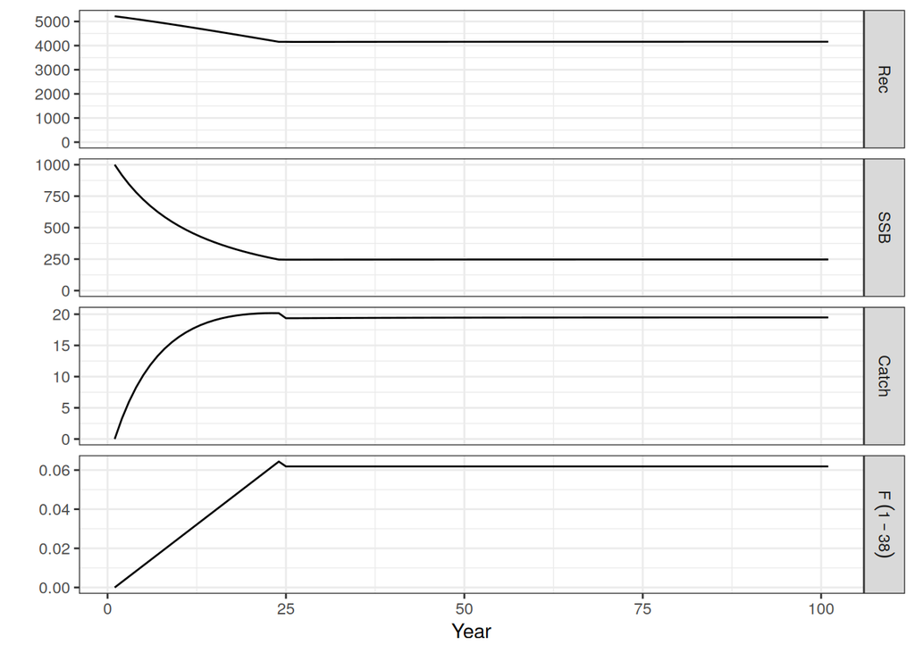

```r
# constant f at Fmsy
fmsy <- c(refpts(brp)["msy", "harvest"])

# apply fishing history to stock
ctrl <- fwdControl(year = 25:101, quant = "f", value = fmsy)
stk0 <- fwd(stk0, control = ctrl, sr = sr)
plot(stk0) + labs(x = "Year") + theme_bw()
```

# 3 Part 2: Deep-sea-like operating model

The OM has three areas: two submarine mounts subject to fishing (`a` and `b`) and one refuge area not subject to fishing (`c`). All three areas belong to the same stock (`sr` and `stk0` from Part 1).

Each scenario below varies the movement rates between areas via `args_om`. The OM setup is based on the following parameters:

- `smpf` — seamount partial f
- `bab` — movement rate from area a to area b
- `bba` — movement rate from area b to area a
- `bac` — movement rate from area a to area c
- `bbc` — movement rate from area b to area c
- `smpra` — seamount a partial R
- `smprb` — seamount b partial R
- `ftrga` — seamount a f target
- `ftrgb` — seamount b f target

Partial recruitment to area c is computed by $1-smpra-smprb$.

There are three scenarios:

1. **Minimum movement**, with the same recruitment across areas. Areas a and b show the same behaviour. Biomass in area c is higher, since recruitment is the same across areas but area c is not fished.
2. **Strong vertical migration**, with the same recruitment across areas. Areas a and b become depleted, with very low biomass and catches reduced to very small amounts. Biomass in area c is very high, since most of the population moves there and it is not fished.
3. **Strong horizontal movement**. Area a (donor) becomes depleted, with very low catches. In this case even recruitment is reduced, since horizontal migration includes recruitment and occurs after the settlement process. Area b (receiver) is in a healthy state, including high recruitment inherited from area a. Area c behaves as in scenario 01.

## 3.1 Scenario 01: minimum movement (by age and time)

```r
args_om <- list(
  smpf = 0.5,     # seamount partial f
  bab = 0.05,     # from a to b
  bba = 0.05,     # from b to a
  bac = 0,        # from a to c
  bbc = 0,        # from b to c
  smpra = 0.333,  # seamount a partial R
  smprb = 0.333,  # seamount b partial R
  ftrga = 0.05,   # seamount a f target
  ftrgb = 0.05    # seamount b f target
)
```

```r
# objects
stka_s01 <- stkb_s01 <- stkc_s01 <- stk_s01 <- stk0
sra.gm <- srb.gm <- src.gm <- as.FLSR(stk_s01, model = "geomean")
harvest(stka_s01) <- harvest(stk_s01) * args_om$smpf
harvest(stkb_s01) <- harvest(stk_s01) * (1 - args_om$smpf)
harvest(stkc_s01)[] <- 0
```

```r
flq0 <- stock.n(stk_s01)
flq0[] <- range(stk_s01)["min"]:range(stk_s01)["max"]
# from a to b
bab <- flq0
bab[] <- args_om$bab
# from b to a
bba <- flq0
bba[] <- args_om$bba
# from a to c
bac <- FLife:::logisticFn(age = flq0, params = FLPar(a50 = a50, asym = 1, ato95 = 1)) * args_om$bac
# from b to c
bbc <- FLife:::logisticFn(age = flq0, params = FLPar(a50 = a50, asym = 1, ato95 = 1)) * args_om$bbc
mov <- FLQuants(bab = bab, bba = bba, bac = bac, bbc = bbc)
```

```r
for (i in 50:100) {
  # common recruitment
  rfut <- predict(sr, ssb = ssb(stk_s01)[, ac(i - 1)])

  # movement
  # from a to b
  stknab <- stock.n(stka_s01)[, ac(i)] * mov[["bab"]][, ac(i)]
  # from b to a
  stknba <- stock.n(stkb_s01)[, ac(i)] * mov[["bba"]][, ac(i)]
  # from a to c
  stknac <- stock.n(stka_s01)[, ac(i)] * mov[["bac"]][, ac(i)]
  # from b to c
  stknbc <- stock.n(stkb_s01)[, ac(i)] * mov[["bbc"]][, ac(i)]

  stock.n(stka_s01)[, ac(i)] <- stock.n(stka_s01)[, ac(i)] - stknab - stknac + stknba
  stock.n(stkb_s01)[, ac(i)] <- stock.n(stkb_s01)[, ac(i)] - stknba - stknbc + stknab
  stock.n(stkc_s01)[, ac(i)] <- stock.n(stkc_s01)[, ac(i)] + stknac + stknbc

  # distribute recruitment evenly
  params(sra.gm)[] <- rfut * args_om$smpra
  params(srb.gm)[] <- rfut * args_om$smprb
  params(src.gm)[] <- rfut * (1 - args_om$smpra - args_om$smprb)

  # set projection at F level of ftrg in the seamounts, area c has
  # harvest = 0, so no F will happen
  ctrl <- fwdControl(year = c(i + 1), quant = "f", value = args_om$ftrga)
  stka_s01 <- fwd(stka_s01, control = ctrl, sr = sra.gm)
  ctrl <- fwdControl(year = c(i + 1), quant = "f", value = args_om$ftrgb)
  stkb_s01 <- fwd(stkb_s01, control = ctrl, sr = srb.gm)
  ctrl <- fwdControl(year = c(i + 1), quant = "f", value = 0)
  stkc_s01 <- fwd(stkc_s01, control = ctrl, sr = src.gm)

  # update stock
  stk_s01 <- stka_s01 + stkb_s01 + stkc_s01
}
```

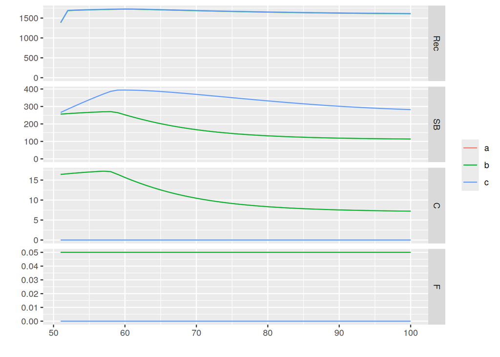

```r
plot(window(FLStocks(a = stka_s01, b = stkb_s01, c = stkc_s01), 51, 100))
```

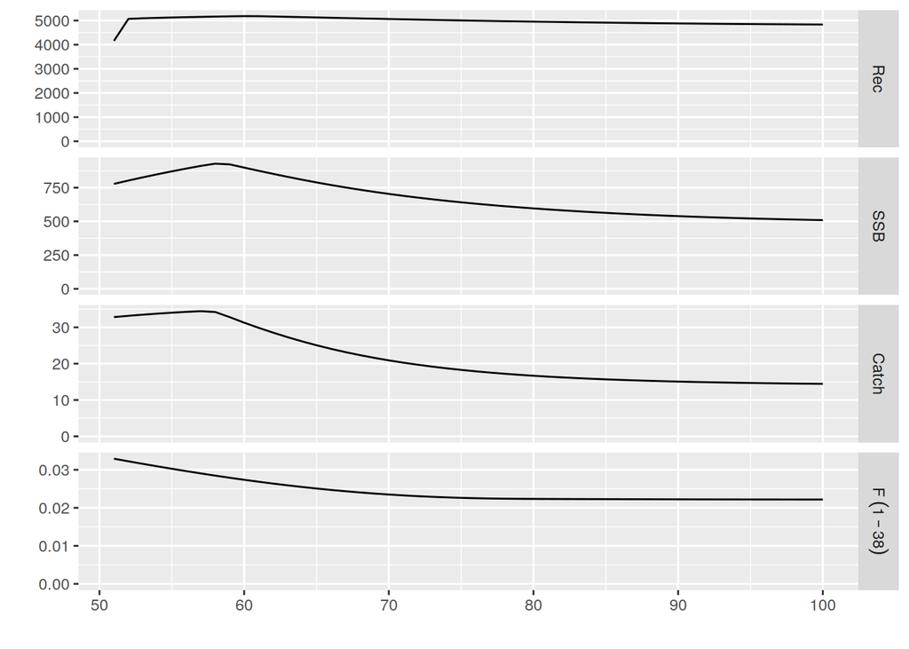

```r
plot(window(stk_s01, 51, 100))
```

## 3.2 Scenario 02: strong vertical migration (by age and time)

```r
args_om <- list(
  smpf = 0.5,     # seamount partial f
  bab = 0.05,     # from a to b
  bba = 0.05,     # from b to a
  bac = 1,        # from a to c
  bbc = 1,        # from b to c
  smpra = 0.333,  # seamount a partial R
  smprb = 0.333,  # seamount b partial R
  ftrga = 0.05,   # seamount a f target
  ftrgb = 0.05    # seamount b f target
)
```

```r
# objects
stka_s02 <- stkb_s02 <- stkc_s02 <- stk_s02 <- stk0
sra.gm <- srb.gm <- src.gm <- as.FLSR(stk_s02, model = "geomean")
harvest(stka_s02) <- harvest(stk_s02) * args_om$smpf
harvest(stkb_s02) <- harvest(stk_s02) * (1 - args_om$smpf)
harvest(stkc_s02)[] <- 0
```

```r
flq0 <- stock.n(stk_s02)
flq0[] <- range(stk_s02)["min"]:range(stk_s02)["max"]
# from a to b
bab <- flq0
bab[] <- args_om$bab
# from b to a
bba <- flq0
bba[] <- args_om$bba
# from a to c
bac <- FLife:::logisticFn(age = flq0, params = FLPar(a50 = a50, asym = 1, ato95 = 1)) * args_om$bac
# from b to c
bbc <- FLife:::logisticFn(age = flq0, params = FLPar(a50 = a50, asym = 1, ato95 = 1)) * args_om$bbc
mov <- FLQuants(bab = bab, bba = bba, bac = bac, bbc = bbc)
```

```r
for (i in 50:100) {
  # common recruitment
  rfut <- predict(sr, ssb = ssb(stk_s02)[, ac(i - 1)])

  # movement
  # from a to b
  stknab <- stock.n(stka_s02)[, ac(i)] * mov[["bab"]][, ac(i)]
  # from b to a
  stknba <- stock.n(stkb_s02)[, ac(i)] * mov[["bba"]][, ac(i)]
  # from a to c
  stknac <- stock.n(stka_s02)[, ac(i)] * mov[["bac"]][, ac(i)]
  # from b to c
  stknbc <- stock.n(stkb_s02)[, ac(i)] * mov[["bbc"]][, ac(i)]

  stock.n(stka_s02)[, ac(i)] <- stock.n(stka_s02)[, ac(i)] - stknab - stknac + stknba
  stock.n(stkb_s02)[, ac(i)] <- stock.n(stkb_s02)[, ac(i)] - stknba - stknbc + stknab
  stock.n(stkc_s02)[, ac(i)] <- stock.n(stkc_s02)[, ac(i)] + stknac + stknbc

  # distribute recruitment evenly
  params(sra.gm)[] <- rfut * args_om$smpra
  params(srb.gm)[] <- rfut * args_om$smprb
  params(src.gm)[] <- rfut * (1 - args_om$smpra - args_om$smprb)

  # set projection at F level of ftrg in the seamounts, area c has
  # harvest = 0, so no F will happen
  ctrl <- fwdControl(year = c(i + 1), quant = "f", value = args_om$ftrga)
  stka_s02 <- fwd(stka_s02, control = ctrl, sr = sra.gm)
  ctrl <- fwdControl(year = c(i + 1), quant = "f", value = args_om$ftrgb)
  stkb_s02 <- fwd(stkb_s02, control = ctrl, sr = srb.gm)
  ctrl <- fwdControl(year = c(i + 1), quant = "f", value = 0)
  stkc_s02 <- fwd(stkc_s02, control = ctrl, sr = src.gm)

  # update stock
  stk_s02 <- stka_s02 + stkb_s02 + stkc_s02
}
```

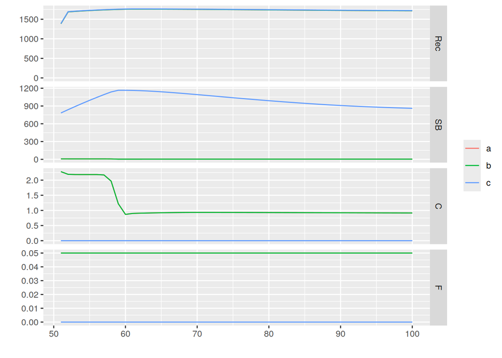

```r
plot(window(FLStocks(a = stka_s02, b = stkb_s02, c = stkc_s02), 51, 100))
```

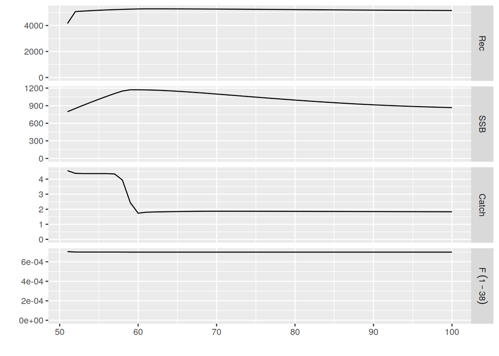

```r
plot(window(stk_s02, 51, 100))
```

## 3.3 Scenario 03: strong horizontal migration (by age and time)

```r
args_om <- list(
  smpf = 0.5,     # seamount partial f
  bab = 0.75,     # from a to b
  bba = 0.05,     # from b to a
  bac = 0,        # from a to c
  bbc = 0,        # from b to c
  smpra = 0.333,  # seamount a partial R
  smprb = 0.333,  # seamount b partial R
  ftrga = 0.05,   # seamount a f target
  ftrgb = 0.05    # seamount b f target
)
```

```r
# objects
stka_s03 <- stkb_s03 <- stkc_s03 <- stk_s03 <- stk0
sra.gm <- srb.gm <- src.gm <- as.FLSR(stk_s03, model = "geomean")
harvest(stka_s03) <- harvest(stk_s03) * args_om$smpf
harvest(stkb_s03) <- harvest(stk_s03) * (1 - args_om$smpf)
harvest(stkc_s03)[] <- 0
```

```r
flq0 <- stock.n(stk_s03)
flq0[] <- range(stk_s03)["min"]:range(stk_s03)["max"]
# from a to b
bab <- flq0
bab[] <- args_om$bab
# from b to a
bba <- flq0
bba[] <- args_om$bba
# from a to c
bac <- FLife:::logisticFn(age = flq0, params = FLPar(a50 = a50, asym = 1, ato95 = 1)) * args_om$bac
# from b to c
bbc <- FLife:::logisticFn(age = flq0, params = FLPar(a50 = a50, asym = 1, ato95 = 1)) * args_om$bbc
mov <- FLQuants(bab = bab, bba = bba, bac = bac, bbc = bbc)
```

```r
for (i in 50:100) {
  # common recruitment
  rfut <- predict(sr, ssb = ssb(stk_s03)[, ac(i - 1)])

  # movement
  # from a to b
  stknab <- stock.n(stka_s03)[, ac(i)] * mov[["bab"]][, ac(i)]
  # from b to a
  stknba <- stock.n(stkb_s03)[, ac(i)] * mov[["bba"]][, ac(i)]
  # from a to c
  stknac <- stock.n(stka_s03)[, ac(i)] * mov[["bac"]][, ac(i)]
  # from b to c
  stknbc <- stock.n(stkb_s03)[, ac(i)] * mov[["bbc"]][, ac(i)]

  stock.n(stka_s03)[, ac(i)] <- stock.n(stka_s03)[, ac(i)] - stknab - stknac + stknba
  stock.n(stkb_s03)[, ac(i)] <- stock.n(stkb_s03)[, ac(i)] - stknba - stknbc + stknab
  stock.n(stkc_s03)[, ac(i)] <- stock.n(stkc_s03)[, ac(i)] + stknac + stknbc

  # distribute recruitment evenly
  params(sra.gm)[] <- rfut * args_om$smpra
  params(srb.gm)[] <- rfut * args_om$smprb
  params(src.gm)[] <- rfut * (1 - args_om$smpra - args_om$smprb)

  # set projection at F level of ftrg in the seamounts, area c has
  # harvest = 0, so no F will happen
  ctrl <- fwdControl(year = c(i + 1), quant = "f", value = args_om$ftrga)
  stka_s03 <- fwd(stka_s03, control = ctrl, sr = sra.gm)
  ctrl <- fwdControl(year = c(i + 1), quant = "f", value = args_om$ftrgb)
  stkb_s03 <- fwd(stkb_s03, control = ctrl, sr = srb.gm)
  ctrl <- fwdControl(year = c(i + 1), quant = "f", value = 0)
  stkc_s03 <- fwd(stkc_s03, control = ctrl, sr = src.gm)

  # update stock
  stk_s03 <- stka_s03 + stkb_s03 + stkc_s03
}
```

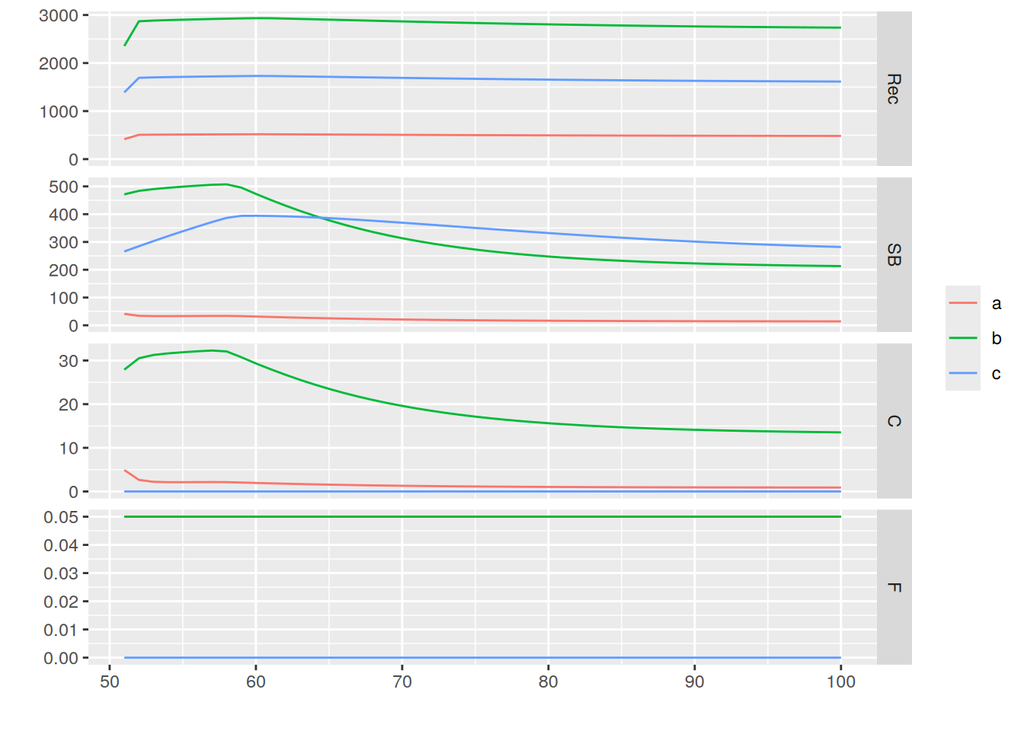

```r
plot(window(FLStocks(a = stka_s03, b = stkb_s03, c = stkc_s03), 51, 100))
```

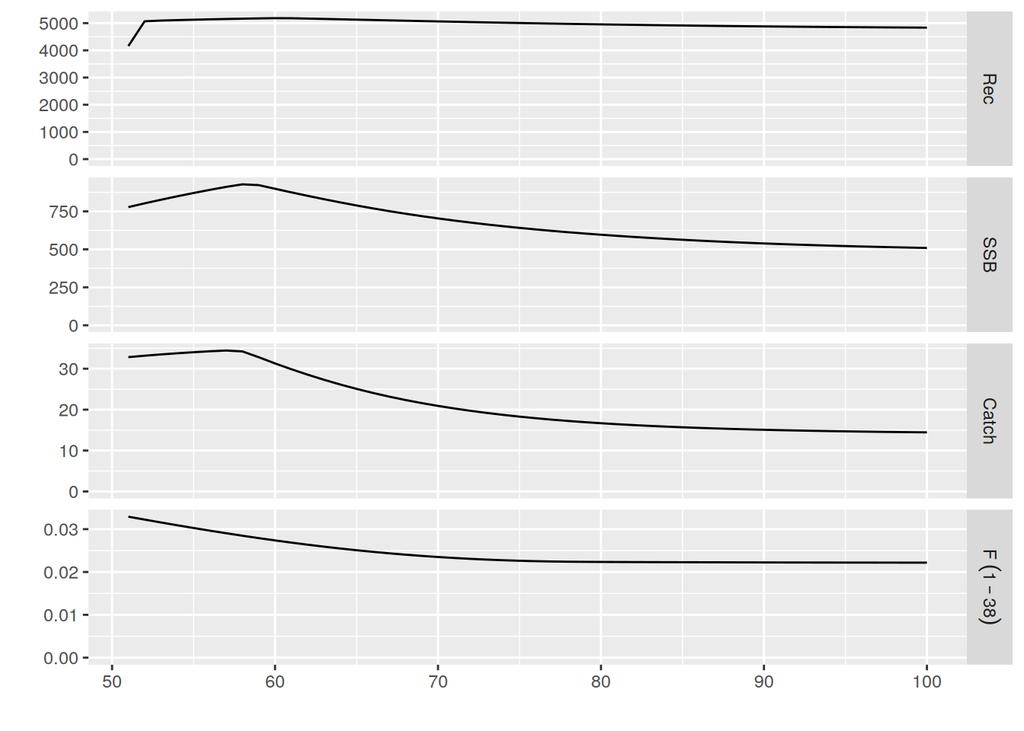

```r
plot(window(stk_s03, 51, 100))
```